# Analysis of Rental Stress Across Australian Regions and Dwelling Types in 2026

ETC5513 – Assignment3

Tin Nguyen, Waranya Ratirotjanakul, Amisha Vatsa, Inayat Gill

2026-06-08

## Problem Introduction

**Why does rental affordability matter?**

- Australia’s rental market has faced sustained pressure from population growth, low vacancy rates, and rising construction costs
- Weekly rents have moved beyond the reach of many low- to middle-income households across metropolitan and regional areas
- Understanding price variation across states and dwelling types is critical for housing policy and renters

**Research Question**

- *Where and in what types of dwellings is rental stress most acute in Australia in 2026?*

## Dataset Description

**Australian Rental Market Data 2026**

- Source: Kaggle
- 6,766 rental listings across Australia
- Covers all states and territories

**Information Available**

- Weekly rental price
- Geographic location
- Dwelling type
- Property characteristics (bedrooms, bathrooms, parking spaces)

**Purpose**

- Examine rental stress across Australian regions and dwelling types

## Methodology

**Data Cleaning**

- Removed 1 duplicate observation
- Excluded variables not relevant to the study
- Retained rental price, location, dwelling type, and property characteristics

**Rental Stress Definition**

- Standard housing affordability benchmark
- Rental stress = weekly rent > 30% of state median weekly household income

**Analysis**

- Compare rental stress across Australian states
- Compare rental stress across dwelling types

## Exploratory Data Analysis

**Key observations**

- New South Wales contains the largest number of rental listings.
- Victoria and Western Australia also contribute substantial number of listings.
- Rental listings are represented across all Australian states and territories.

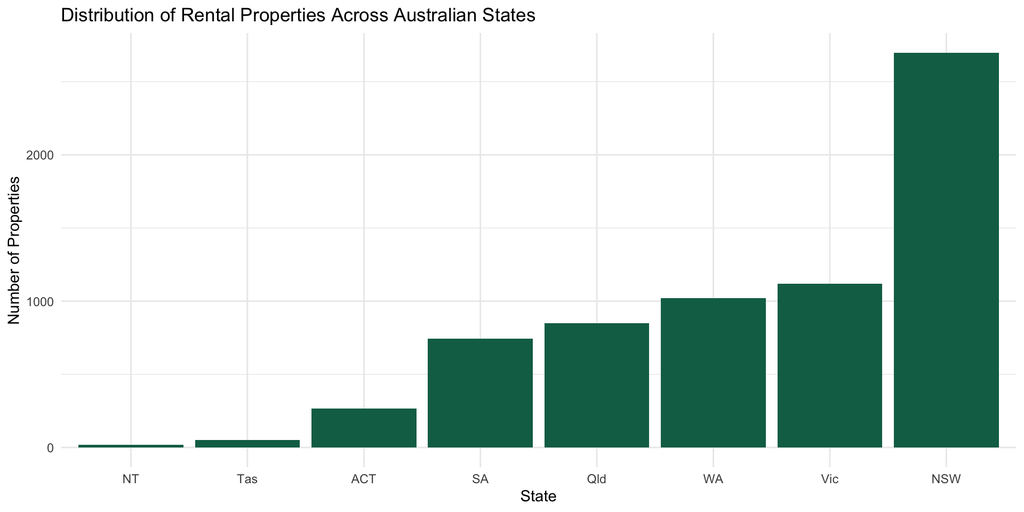

## Results: Rental Stress Across Australian States

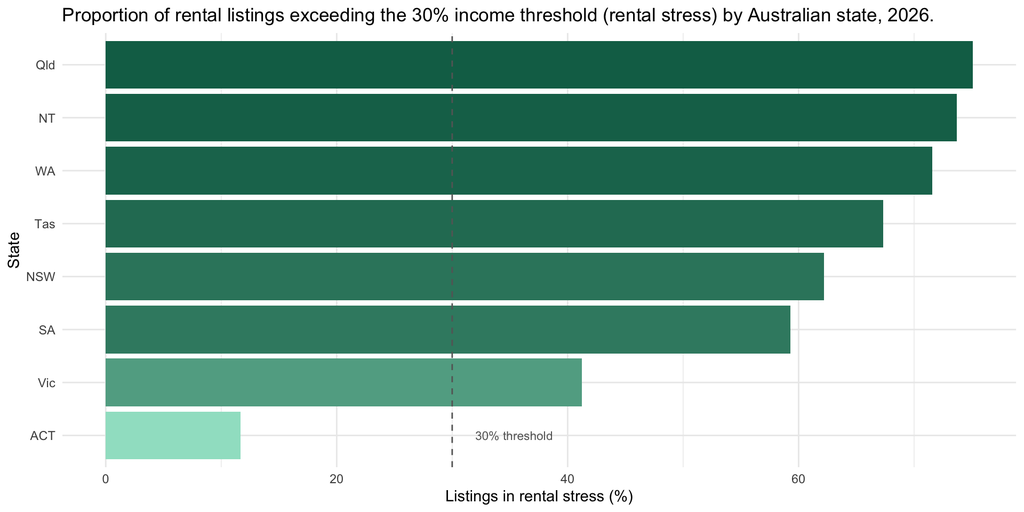

## Results: Rental Stress Across Dwelling Types

- **Acreage/semi-rural** properties had the highest stress rate (88.2%) and median rent ($970/wk)
- **Houses** (65.2%) and **apartments** (63.1%) — the most common types — also recorded high stress
- **Studios** were the most affordable: 11.5% stress rate and $430/wk median rent

Table 1: Rental stress rate and median weekly rent by dwelling type.

| Property type | Number of listings | Median rent ($/wk) | Stress rate (%) |
| --- | --- | --- | --- |
| acreage/semi-rural | 17 | 970 | 88.2 |
| terrace | 7 | 750 | 71.4 |
| townhouse | 142 | 700 | 65.5 |
| house | 4089 | 695 | 65.2 |
| apartment | 1369 | 700 | 63.1 |
| duplex/semi-detached | 134 | 650 | 51.5 |
| villa | 25 | 590 | 44.0 |
| unit | 761 | 550 | 36.5 |
| other | 33 | 540 | 21.2 |
| flat | 85 | 510 | 11.8 |
| studio | 104 | 430 | 11.5 |

## Conclusion

**Key takeaways from the analysis**

**Dwelling type findings**

- Acreage and semi-rural properties are well beyond reach for most renters
- Even mainstream options — houses and apartments — are increasingly unaffordable
- Studios offer the most accessible entry point, but represent a small share of listings

> Rental unaffordability in Australia in 2026 is both **widespread and structurally entrenched**, varying meaningfully by geography and dwelling type

## Recommendations

**Policy Priorities for Australia’s Rental Market**

🏛️ **Target high-stress states**

- Expand Commonwealth Rent Assistance calibrated to state-level incomes
- Priority states: Queensland, Western Australia, and Tasmania

🏗️ **Increase affordable supply**

- Prioritise studios and one-bedroom apartments in high-stress states
- Enable growth through rezoning and density incentives

🏘️ **Address mainstream housing**

- Invest in build-to-rent and social housing schemes
- Introduce inclusionary zoning for new house and apartment developments